# brms analysis

Dan Bruzzese

6/27/2020

# Bayesian Model

Collapsed all 35 chc measurements into a value column with a corresponding chc column detailing what chc was measured. Fitted a model to evaluate the efect of host and sex on chc values. The model accounts for uneven site effects and individual effects.

#1 value ~ hostRace + (1|site) +(1|chc) + (1|ID)  
#2 value ~ hostRace + sex + (1|site) +(1|chc) + (1|ID)  
#3 value ~ hostRace * sex + (1|site) +(1|chc) + (1|ID)  
#4 value ~ hostRace * sex + (1|site) + (1|ID) +(1+ hostRace * sex |chc)

model 4 is the best fit to the data. Verified as the best model with loo comparisons. Model 4 has hostRace, sex, and their interaction as fixed effects. Site and ID are random effects, and chcs are a grouping effect for hostRace and sex.

### Model Converged

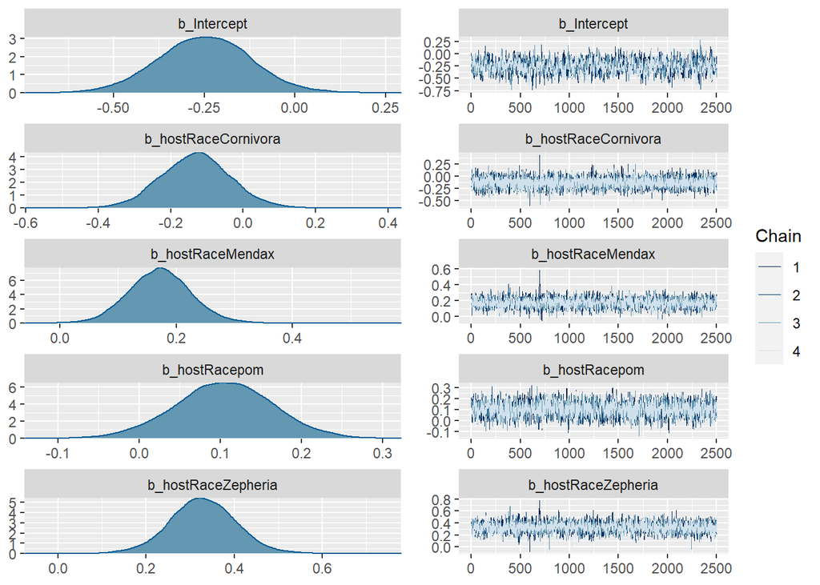

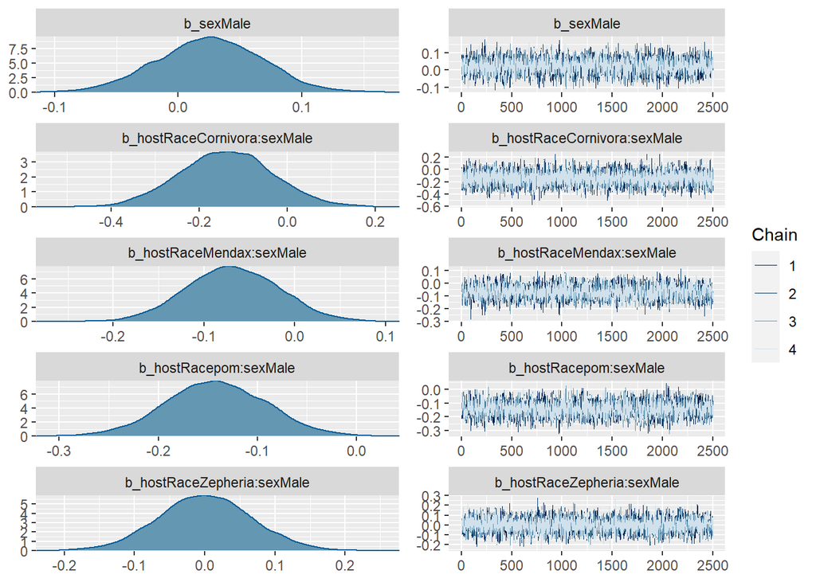

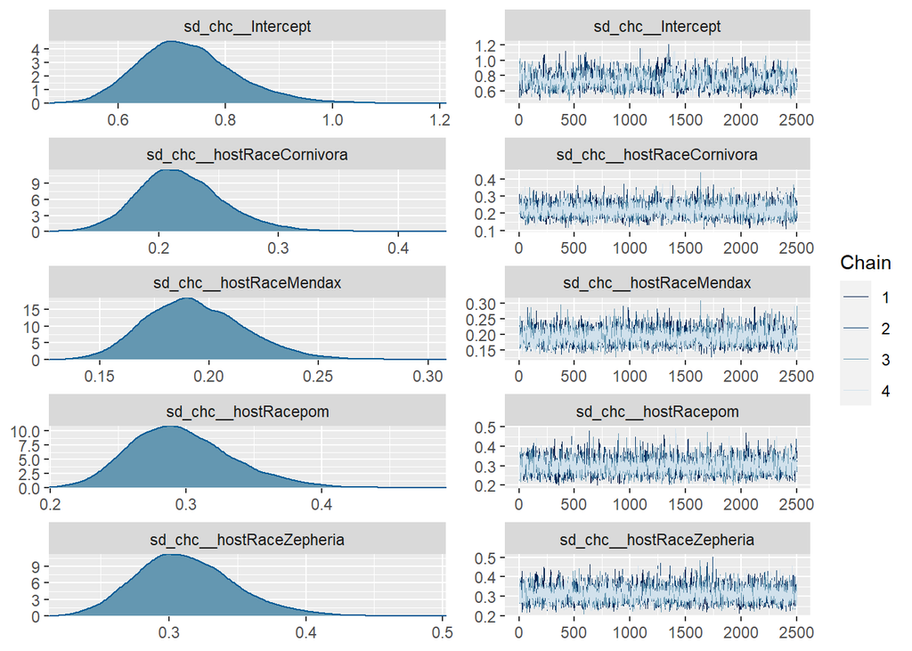

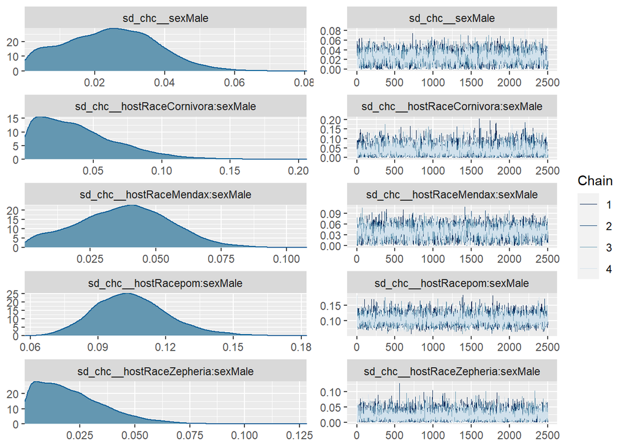

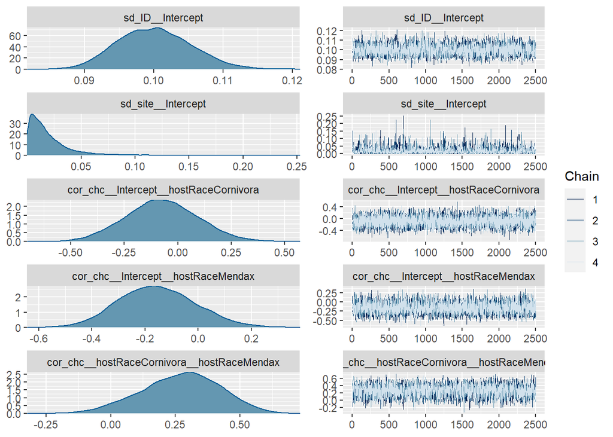

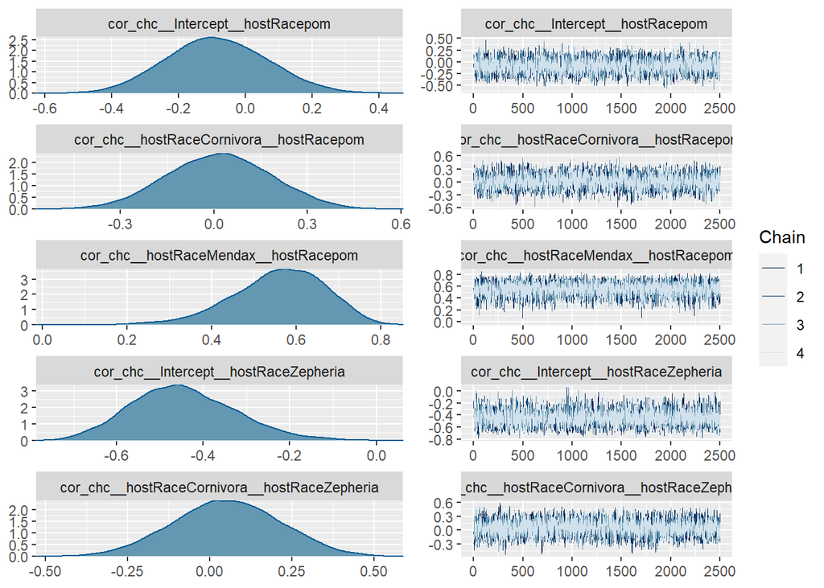

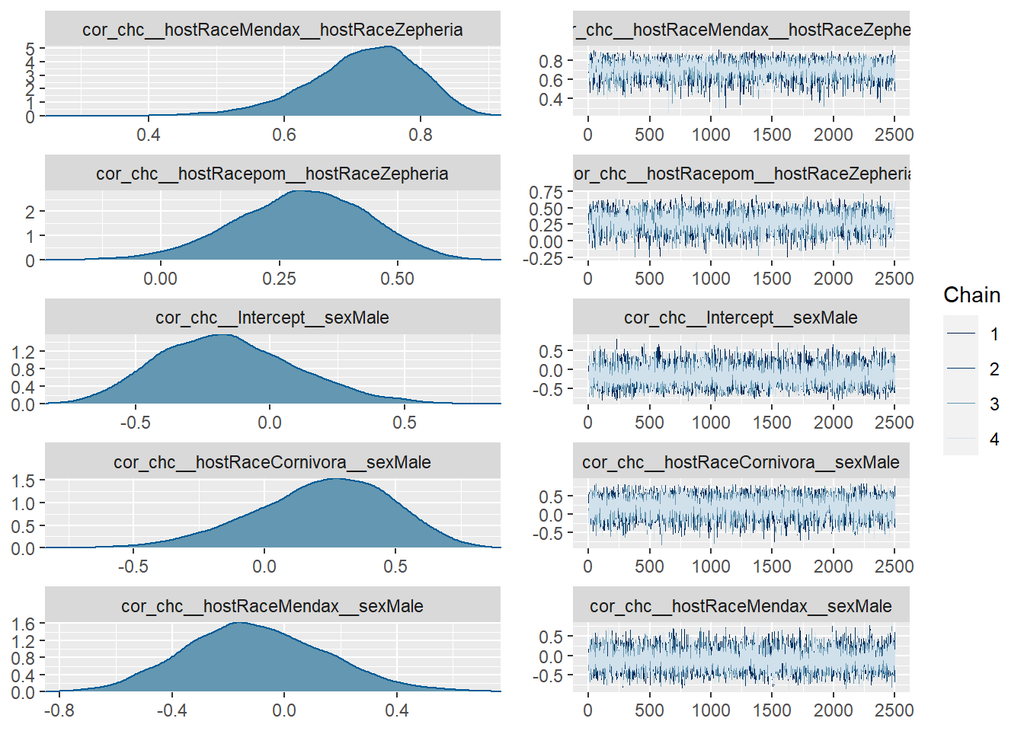

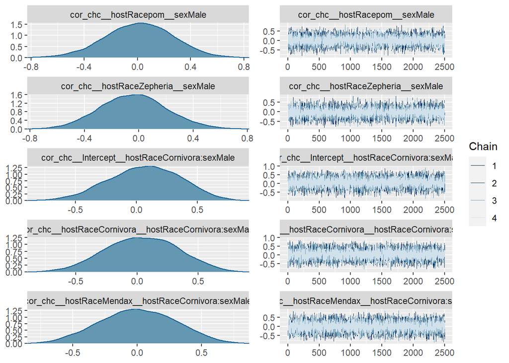

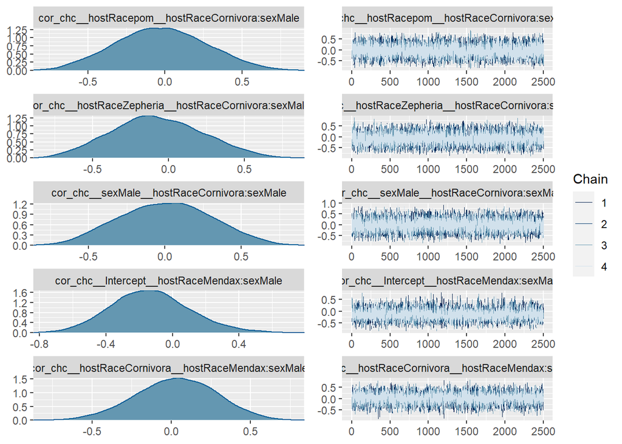

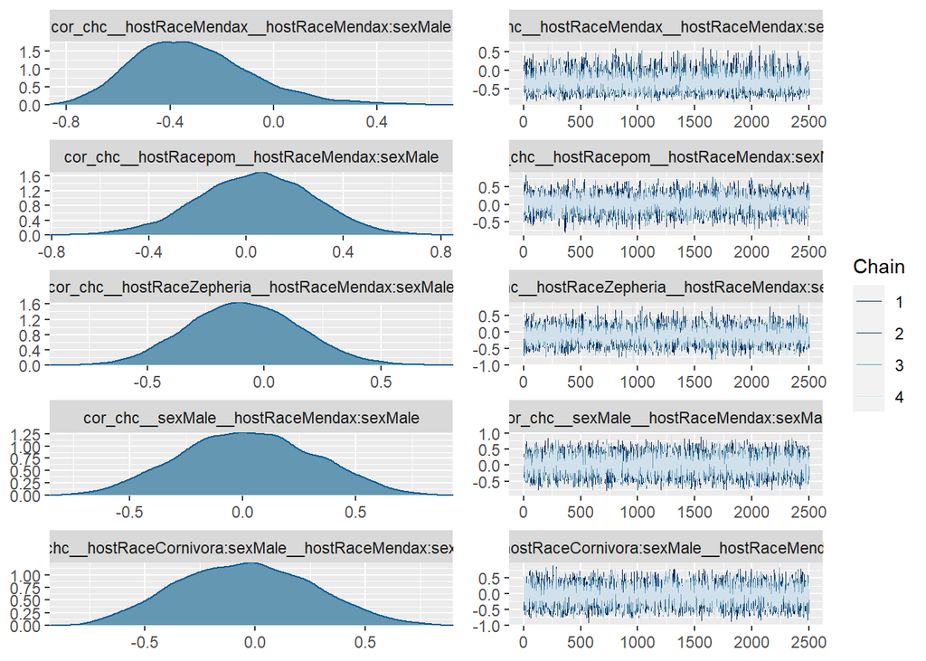

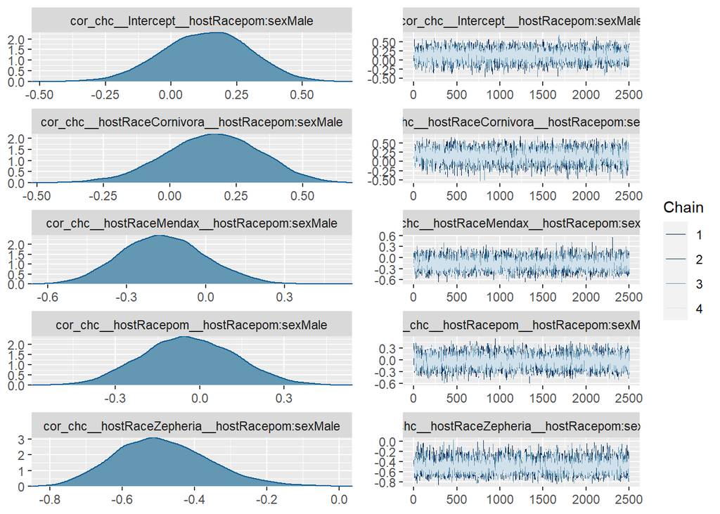

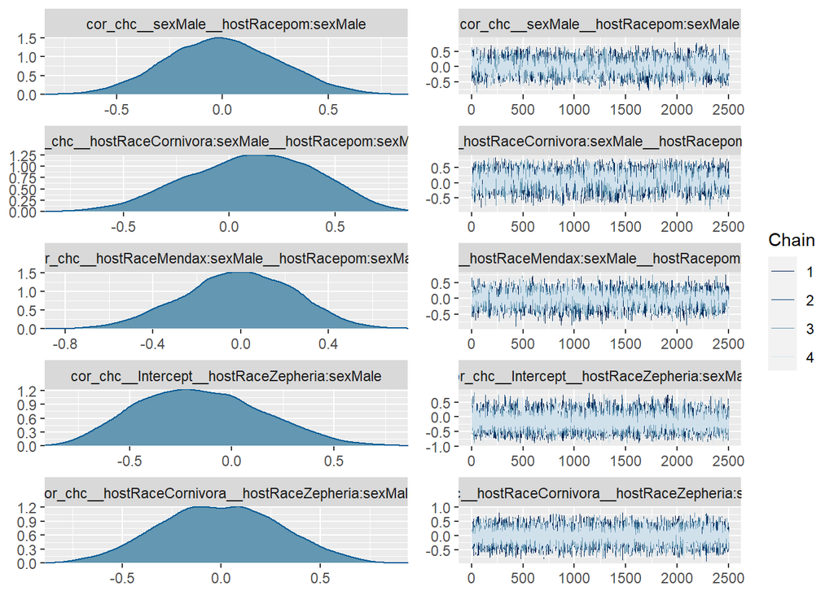

[2 more figures not shown]

### model fit is good = posterior values match real values

```
## Using 10 posterior samples for ppc type 'dens_overlay' by default.
```

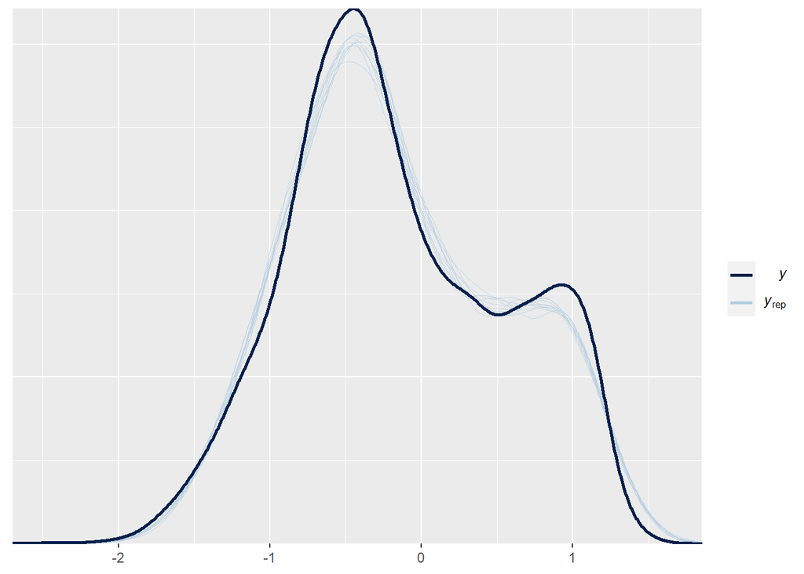

### Model fit is good = r2 == 92%

```
##     Estimate    Est.Error      Q2.5     Q97.5
## R2 0.9215449 0.0005724438 0.9204093 0.9226447
```

### model summary

|  | value |  |
| --- | --- | --- |
| Predictors | Estimates | CI (95%) |
| Intercept | -0.25 | -0.50 – 0.00 |
| hostRace: Cornivora | -0.13 | -0.32 – 0.06 |
| hostRace: Mendax | 0.17 | 0.07 – 0.28 |
| hostRace: pom | 0.10 | -0.02 – 0.22 |
| hostRace: Zepheria | 0.33 | 0.18 – 0.48 |
| sex: Male | 0.03 | -0.06 – 0.11 |
| hostRaceCornivora.sexMale | -0.14 | -0.34 – 0.07 |
| hostRaceMendax.sexMale | -0.07 | -0.17 – 0.03 |
| hostRacepom.sexMale | -0.14 | -0.24 – -0.04 |
| hostRaceZepheria.sexMale | 0.00 | -0.13 – 0.13 |
| Random Effects |  |  |
| σ<sup>2</sup> | 0.46 |  |
| τ<sub>00</sub> | 0.05 |  |
| ICC | 0.90 |  |
| N <sub>site</sub> | 8 |  |
| N <sub>ID</sub> | 231 |  |
| N <sub>chc</sub> | 35 |  |
| Observations | 8085 |  |
| Marginal R<sup>2</sup> / Conditional R<sup>2</sup> | 0.022 / 0.922 |  |

### two way fixed effect interactions 95% CI

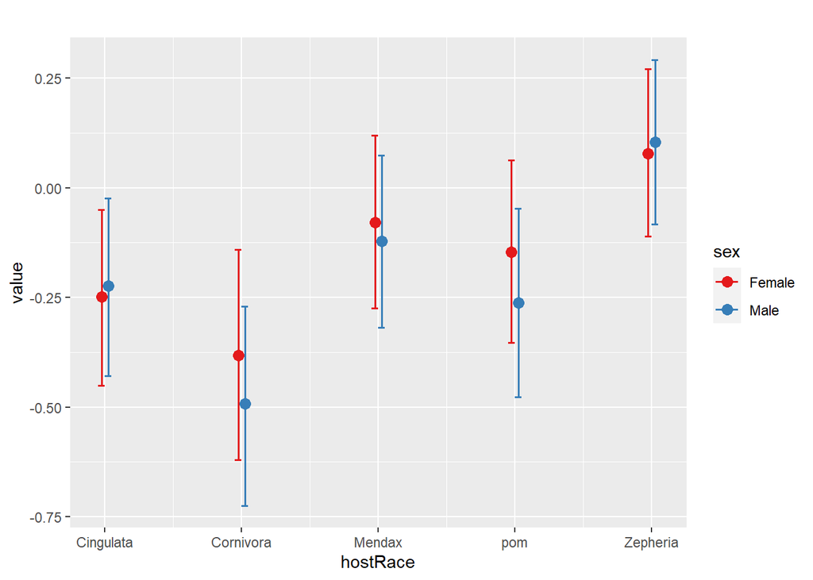

### chc differences btwn host species

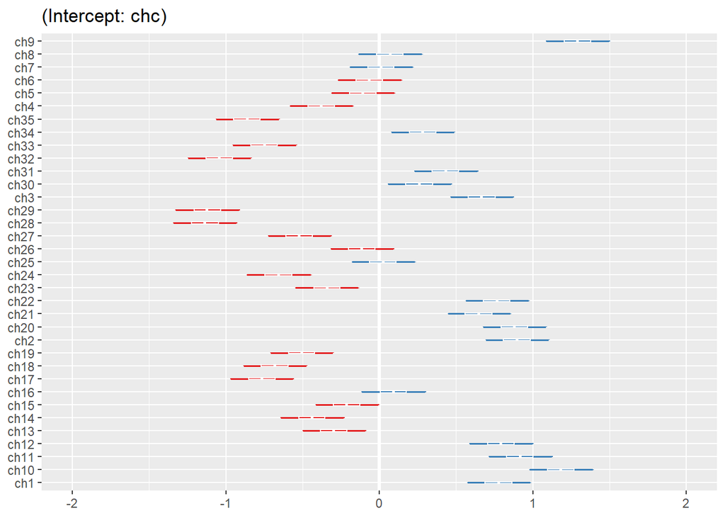

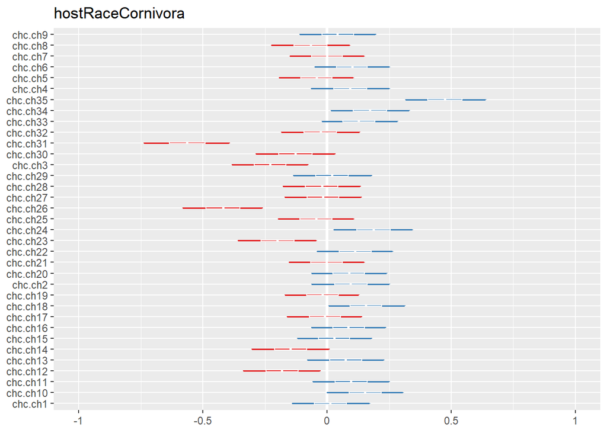

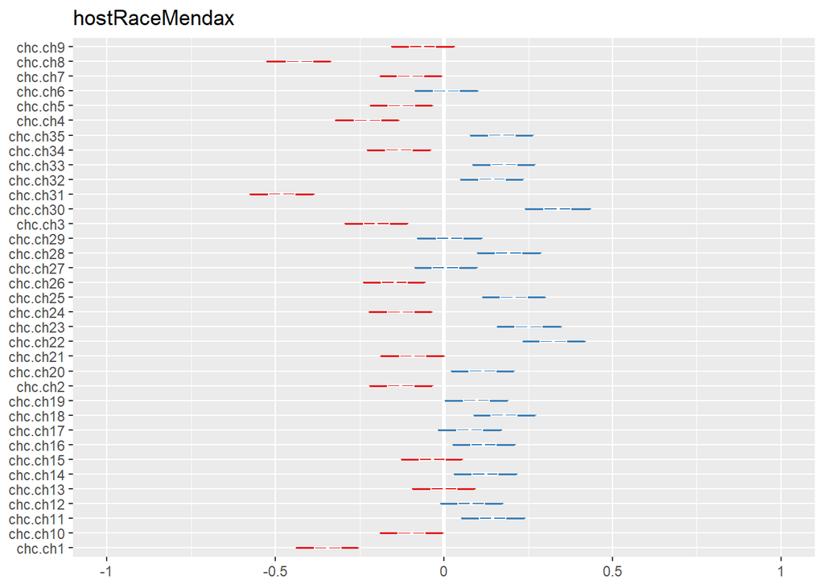

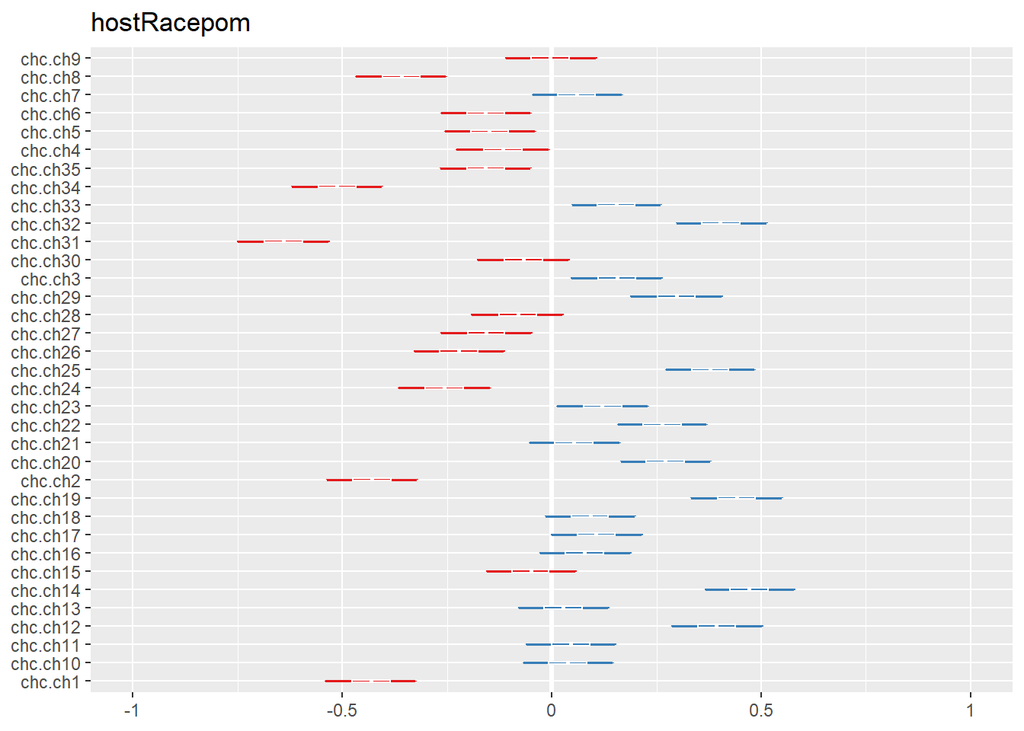

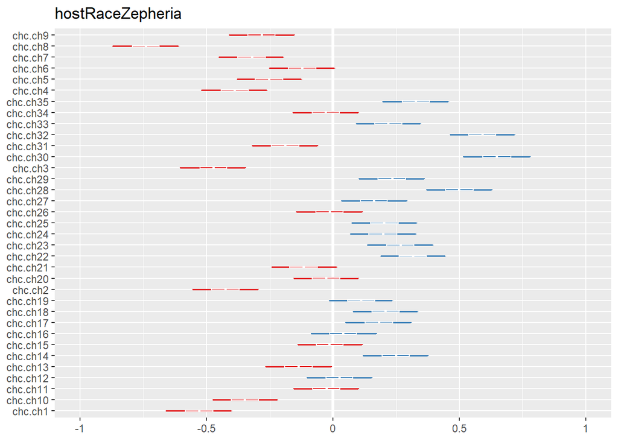

### chc differences btwn host species and sex

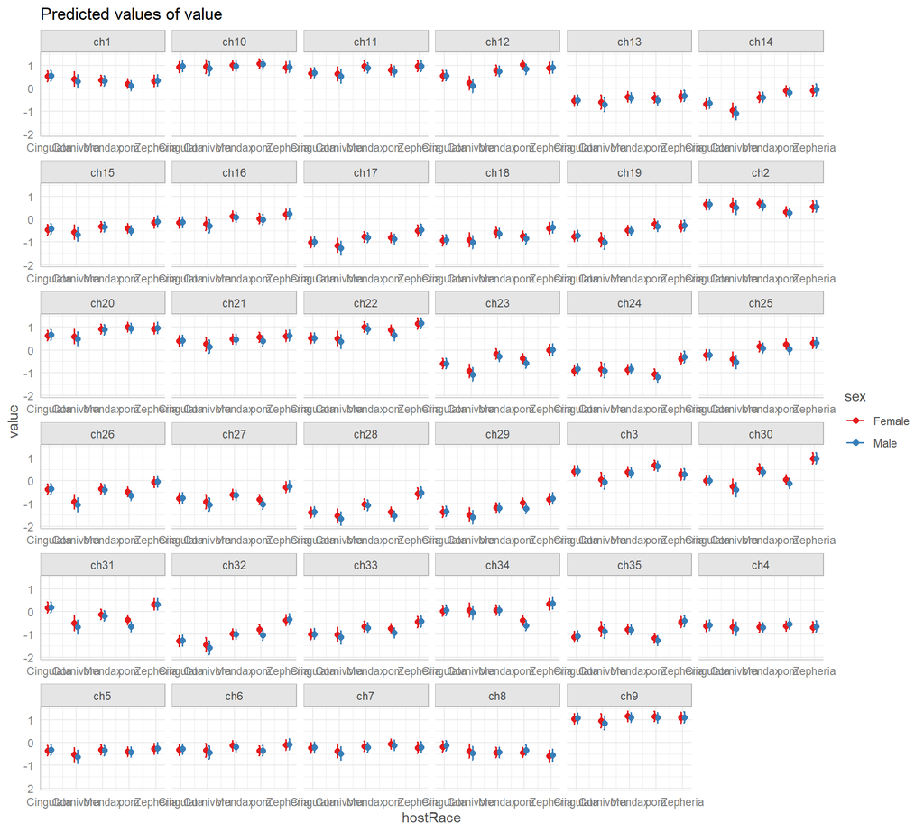